# STAT 5361 - Homework 2

Kristen Sandberg[^1]

06 February 2018

### Problem 1

The Cauchy$(\theta, 1)$ distribution has probability density
$$\begin{align}
p(x;\theta) = \dfrac{1}{\pi[1 + (x - \theta)^2]}, \,\, x \in \mathbb{R}, \,\, \theta \in \mathbb{R}.
\tag{1}
\end{align}$$

#### Problem 1(a)

Let $x_1, \ldots, x_n$ be an i.i.d. sample and $l(\theta)$ the log-likelihood of $\theta$ based on the sample. Show that
$$\begin{align}
l(\theta) &= -n\ln{\pi} - \sum_{i=1}^{n} \ln{[1 + (x - \theta)^2]}, \\
l'(\theta) &= -2 \sum_{i=1}^{n} \dfrac{\theta - x_i}{1 + (x - \theta)^2}, \\
l''(\theta) &= -2 \sum_{i=1}^{n} \dfrac{1 - (\theta - x_i)^2}{[1 + (x - \theta)^2]^2}, \\
I(\theta) &= n \int \dfrac{\{p'(x)\}^2}{p(x)}dx = \dfrac{4n}{\pi} \int_{-\infty}^{\infty} \dfrac{x^2 dx}{(1 + x^2)^3} = \dfrac{n}{2}.
\tag{2}
\end{align}$$

#### Problem 1(b)

Suppose that the observed sample is

```r
x_q1 <- c(1.77, -0.23, 2.76, 3.80, 3.47, 56.75, -1.34, 4.24, -2.44, 3.29, 3.71, -2.40, 4.53, -0.07, -1.05, -13.87, -2.53, -1.75)
```

Graph the log-likelihood function. Find the MLE for $\theta$ using the Newton-Raphson method. Try all the following starting points: $-11, -1, 0, 1.5, 4, 4.7, 7, 8,$ and $38$. Compare your results. Is the sample mean a good starting point?

#### Solution 1(b)

Table 1: The MLE for $\theta$ using the Newton-Raphson method.

| Starting Point | Converges to |
| --- | --- |
| -11.0000 | -3.660385e+30 |
| -1.0000 | -5.915000e-01 |
| 0.0000 | -5.915000e-01 |
| 1.5000 | 1.092700e+00 |
| 4.0000 | 3.021300e+00 |
| 4.7000 | -5.915000e-01 |
| 7.0000 | 1.527426e+30 |
| 8.0000 | 8.084521e+29 |
| 38.0000 | 1.135250e+31 |
| 3.2578 | 3.021300e+00 |

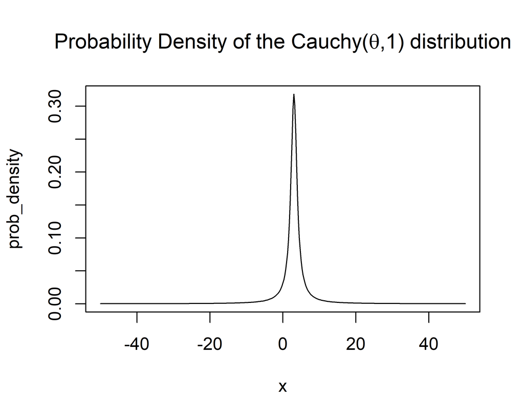

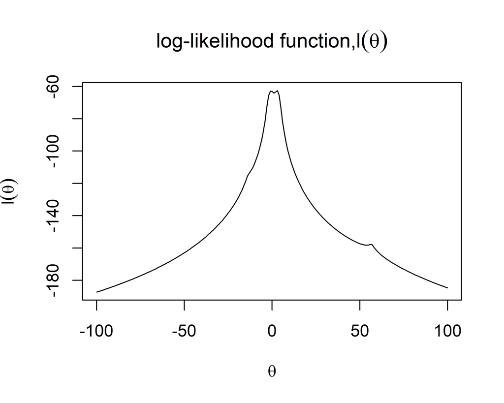

#### Problem 1(c)

Apply fixed-point iterations using $G(x) = \alpha l'(\theta) + \theta$, with scaling choices of $\alpha \in \{1, 0.64, 0.25\}$ and initial value $-1$. Try the same starting points as above.

#### Solution 1(c)

When we apply the fixed-point iteration method with $G(\theta) = \alpha l'(\theta) + \theta$, with scaling choices of $\alpha \in \{1, 0.64, 0.25\}$, we find the following results in Table 2.

Table 2: The results of the fixed-point iterations using $G(x) = \alpha l'(\theta) + \theta$ where $\alpha \in \{1, 0.64, 0.25\}$.

| Starting Point | Alpha | Attracted to Theta |
| --- | --- | --- |
| -1 | 1.00 | 0.1035 |
| -1 | 0.64 | -0.5915 |
| -1 | 0.25 | -0.5915 |
| -11 | 1.00 | -0.5915 |
| -11 | 0.64 | -0.5915 |
| -11 | 0.25 | -0.5915 |
| 0 | 1.00 | -1.1063 |
| 0 | 0.64 | -0.5915 |
| 0 | 0.25 | -0.5915 |

| Starting Point | Alpha | Attracted to Theta |
| --- | --- | --- |
| 1.5 | 1.00 | 0.1035 |
| 1.5 | 0.64 | 3.2398 |
| 1.5 | 0.25 | 3.0213 |
| 4.0 | 1.00 | -1.1063 |
| 4.0 | 0.64 | -0.5915 |
| 4.0 | 0.25 | 3.0213 |
| 4.7 | 1.00 | -1.1714 |
| 4.7 | 0.64 | -0.5915 |
| 4.7 | 0.25 | 3.0213 |

| Starting Point | Alpha | Attracted to Theta |
| --- | --- | --- |
| 7 | 1.00 | -1.1714 |
| 7 | 0.64 | 2.5915 |
| 7 | 0.25 | 3.0213 |
| 8 | 1.00 | 0.2417 |
| 8 | 0.64 | -0.5915 |
| 8 | 0.25 | 3.0213 |
| 38 | 1.00 | 0.2417 |
| 38 | 0.64 | 2.5915 |
| 38 | 0.25 | 3.0213 |

#### Problem 1(d)

First use Fisher scoring to find the MLE for $\theta$, then refine the estimate by running Newton-Raphson method. Try the same starting points as above.

#### Solution 1(d)

We found that the starting points converged to two maxima, one of which was the global maximum, or MLE.

Table 3: The results of using Fisher scoring to find the MLE from different starting points are shown in the table.

| Starting Point | Converges to |
| --- | --- |
| -11.00000 | -0.59147 |
| -1.00000 | -0.59147 |
| 0.00000 | -0.59147 |
| 1.50000 | 3.02135 |
| 4.00000 | 3.02135 |
| 4.70000 | 3.02135 |
| 7.00000 | 3.02135 |
| 8.00000 | 3.02135 |
| 38.00000 | 3.02135 |
| 3.25778 | 3.02135 |

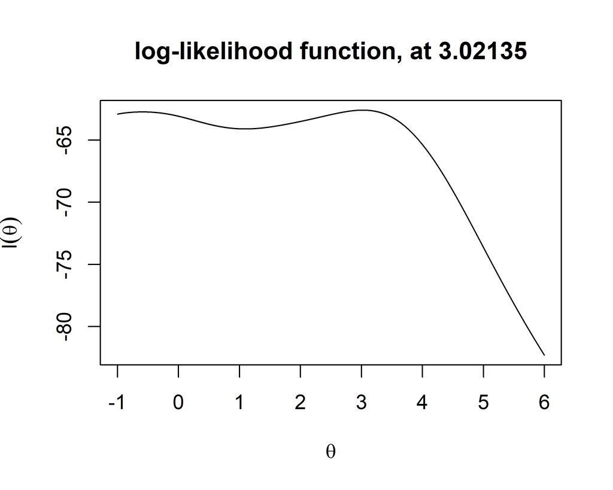

Table 3: The result of using the Newton-Raphson method to refine our results from the Fisher scoring method is shown in the table.

| Starting Point from Fisher Scoring | Converges to using Newton-Raphson |
| --- | --- |
| 3.021345443231597816 | 3.0213454432315973719 |

Using Fisher scoring, we found the MLE to be $\theta =$ 3.021345443231597816. Once we refined this estimate using the Newton-Raphson method, we found the MLE to be $\theta =$ 3.0213454432315973719.

#### Problem 1(e)

Comment on the results from different methods (speed, stability, etc.).

### Problem 2

Consider the probability density with parameter $\theta$
$$\begin{align}
p(x;\theta) = \dfrac{1-\cos{(x-\theta)}}{2\pi}, \,\, 0\leq x \leq 2\pi , \,\, \theta \in (-\pi,\pi).
\tag{3}
\end{align}$$

A random sample from the distribution is

```r
x_q2 <- c(3.91, 4.85, 2.28, 4.06, 3.70, 4.04, 5.46, 3.53, 2.28, 1.96,
       2.53, 3.88, 2.22, 3.47, 4.82, 2.46, 2.99, 2.54, 0.52)
```

#### Problem 2(a)

What is the log-likelihood function of $\theta$ based on the sample? Graph the function between $-\pi$ and $\pi$.

#### Solution 2(a)

The log-likelihood function of $\theta$ based on the given sample can be computed as follows:
$$\begin{align}
l(\theta) &= \ln{\left[\prod_{i=1}^{n} \left(\dfrac{1-\cos{(x-\theta)}}{2\pi}\right)\right]} \\
&= \sum_{i=1}^{n} \left[\ln{\left(\dfrac{1-\cos{(x-\theta)}}{2\pi}\right)}\right] \\
&= \sum_{i=1}^{n} \left[\ln{\left(\dfrac{1}{2\pi}\right)} + \ln{\left(1-\cos{(x-\theta)}\right)}\right] \\
&= n\ln{\left(\dfrac{1}{2\pi}\right)} + \sum_{i=1}^{n} \left[\ln{\left(1-\cos{(x-\theta)}\right)}\right] \\
&= n\ln{\left(1\right)} - n\ln{\left(2\pi\right)} + \sum_{i=1}^{n} \left[\ln{\left(1-\cos{(x-\theta)}\right)}\right] \\
&= - n\ln{\left(2\pi\right)} + \sum_{i=1}^{n} \left[\ln{\left(1-\cos{(x-\theta)}\right)}\right].
\tag{4}
\end{align}$$
The graph of the log-likelihood function of $\theta$ is plotted from $[-\pi,\pi]$ in Figure 1.

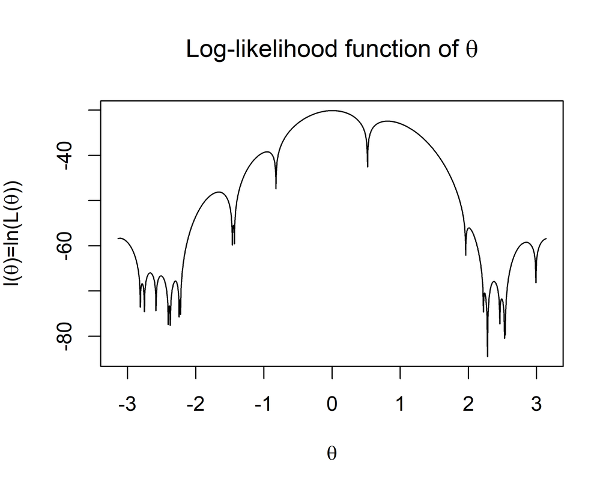

Figure 1: Log-likelihood function

#### Problem 2(b)

Find the method-of-moments estimator of $\theta$. That is, the estimator $\hat{\theta}_{\text{moment}}$ is value of $\theta$ with $\mathbb{E}[X | \theta] = \bar{x}$ where x is the sample mean. This means you have to first find the expression for $\mathbb{E}[X | \theta]$.

#### Solution 2(b)

To find the method-of-moments estimator of $\theta$, we will first find the expression for $\mathbb{E}[X | \theta]$, as shown below:

$$\begin{align}
\mathbb{E}[X | \theta] &= \int_{0}^{2\pi} x p(x;\theta) dx \\
&= \dfrac{1}{2\pi}\int_{0}^{2\pi} x (1-\cos{(x-\theta)}) dx \\
&= \dfrac{1}{2\pi}\left[\int_{0}^{2\pi} x dx - \int_{0}^{2\pi}x\cos{(x-\theta)} dx\right] \\
\tag{5}
\end{align}$$

Using integration by parts, we find that

$$\begin{align}
\mathbb{E}[X | \theta] &= \dfrac{1}{2\pi}\left[\dfrac{x^2}{2} \Big|_{0}^{2\pi} - x\sin{(x-\theta)}\Big|_{0}^{2\pi} + \int_{0}^{2\pi} \sin{(x-\theta)}dx \right] \\
&= \left(\dfrac{4\pi^2}{4\pi} - 0\right) - \dfrac{1}{2\pi}\left[2\pi\sin{(2\pi-\theta)}-0\right] - \dfrac{1}{2\pi}\left[ \cos{(x-\theta)} \right]\Big|_{0}^{2\pi} \\
&= \pi - \sin{(2\pi - \theta)} - \dfrac{1}{2\pi}\left[\cos{(2\pi-\theta)} - \cos{(0-\theta)} \right] \\
&= \pi - \left[\sin{(2\pi)}\cos{(-\theta)}+\cos{(2\pi)}\sin{(-\theta)}\right] \\
&- \frac{1}{2\pi}\left[\cos{(2\pi)}\cos{(-\theta)} - \sin{(2\pi)}\sin{(-\theta)}\right] + \frac{1}{2\pi}\left[\cos{(0)}\cos{(-\theta)} - \sin{(0)}\sin{(-\theta)}\right] \\
&= \pi - \sin{(-\theta)} - \dfrac{1}{2\pi}\cos{(-\theta)} + \dfrac{1}{2\pi}\cos{(-\theta)} \\
&= \pi - \sin{(-\theta)} \\
&= \pi - \sin{(\theta)}.
\tag{6}
\end{align}$$
Now we set this equal to the sample mean, $\bar{x}$, and we have
$$\begin{align}
\mathbb{E}[X | \theta] &= \pi - \sin{(\theta)} = \bar{x},
\tag{7}
\end{align}$$
so we subtract $\pi$ from both sides and we have
$$\begin{align}
-\sin{(\theta)} &= \bar{x} - \pi.
\tag{8}
\end{align}$$
Finally we multiply by $-1$ and take the inverse sine function of both sides and we find that
$$\begin{align}
\theta &= \arcsin{(\pi - \bar{x})}.
\tag{8}
\end{align}$$

Thus, the method-of-moments estimator of $\theta$, denoted $\hat{\theta}_{\text{moment}} = \arcsin{(\pi - \bar{x})}$.

Given the observations, the sample mean of the given random sample is $\bar{x}=$ 3.2368421. The method-of-moments estimator of $\theta$ is $\hat{\theta}_{\text{moment}}=$ -0.0953941

#### Problem 2(c)

Find the MLE for $\theta$ using the Newton-Raphson method with $\theta_0 = \hat{\theta}_{\text{moment}}$.

#### Solution 2(c)

When we start with $\theta_0 = \hat{\theta}_{\text{moment}}=$ -0.0953941 we find that the MLE for $\theta$ using the Newton-Raphson method is 0.0031182.

#### Problem 2(d)

What solutions do you find when you start at $\theta_0 = -2.7$ and $\theta_0 = 2.7$?

#### Solution 2(d)

When we start with $\theta_0 = -2.7$ we find that the MLE for $\theta$ using the Newton-Raphson method is -2.6688575 and when $\theta_0 = 2.7$ the MLE is 2.8484153.

#### Problem 2(e)

Repeat the above using 200 equally spaced starting values between $-\pi$ and $\pi$. Partition the values into sets of attraction, That is, divide the set of starting values into separate groups, with each group corresponding to a separate unique outcome of the optimization.

#### Solution 2(e)

Using 200 equally spaced starting values between $-\pi$ and $\pi$, I found the following unique outcomes and divided the set into groups that are attracted to the same outcome.

Table 4: The unique outcomes of the optimization using 200 equally spaced starting values between $-\pi$ and $\pi$. The table lists the lower and upper bounds of values for $\theta$ that are attracted to each unique outcome.

| Attracted to Theta | Lowest Theta in Set | Highest Theta in Set |
| --- | --- | --- |
| -3.1125 | -3.1416 | -2.8259 |
| -2.7866 | -2.7943 | -2.7627 |
| -2.6689 | -2.7311 | -2.6048 |
| -2.5094 | -2.5733 | -2.4154 |
| -2.3883 | -2.3838 | -2.3838 |
| -2.2979 | -2.3522 | -2.2575 |
| -2.2322 | -2.2260 | -2.2260 |
| -1.6627 | -2.1944 | -1.4682 |
| -1.4475 | -1.4366 | -1.4366 |
| -0.9544 | -1.4050 | -0.8367 |
| 0.0031 | -0.8051 | 0.4894 |
| 0.8126 | 0.5210 | 1.9418 |
| 2.0072 | 1.9734 | 2.1944 |
| 2.2370 | 2.2260 | 2.2575 |
| 2.3747 | 2.2891 | 2.4470 |
| 2.4884 | 2.4785 | 2.5101 |
| 2.8484 | 2.5417 | 2.9837 |
| 3.1707 | 3.0153 | 3.1416 |

### Problem 3

The counts of a floor beetle at various time points (in days) are given in a dataset.

```r
beetles <- data.frame(
  days = c(0, 8, 28, 41, 63, 69, 97, 117, 135, 154),
  beetles = c(2, 47, 192, 256, 768, 896, 1120, 896, 1184, 1024))
```

#### Problem 3(a)

Fit the population growth model to the beetles data using the Gauss-Newton approach, to minimize the sum of squared errors between model predictions and observed counts.

#### Problem 3(b)

Show the contour plot of the sum of squared errors.

#### Problem 3(c)

In many population modeling application, an assumption of lognormality is adopted. That is , we assume that $\log{N_t}$ are independent and normally distributed with mean $\log{f(t)}$ and variance $\sigma^2$. Find the maximum likelihood estimators of $r$, $K$, $\sigma^2$ using any suitable method of your choice. Estimate the variance your parameter estimates.

### Acknowledgment

I would like to thank Surya Eada for his collaboration on problem 1a of this assignment prior to when the groups were split up.

### Reference

[^1]: kristen.sandberg@uconn.edu; M.S. in Applied Financial Mathematics, Department of Mathematics, University of Connecticut.